# Mutational burden in normal human small intestine

Yichen Wang

This analysis aims to assess 1) the rate of SBS and ID mutations, 2) the presence and the rate of mutaional burden of mutational sigantures in normal small intestine.

We build linear mixed models for estimating mutation rates. Model parameters encoded are: age, biopsy region (duodenum, jejunum, ileum) , celieac condition (having a coeliac history or not) and patient. We have corrected for coverage by normalising ID and SBS mutational burden according to the sensitivity of detection in each samples before modelling, therfore we do not include it as a parameter for modelling.

## 1.Overview of dataset

```r
library(ggplot2)
library(RColorBrewer)
library(nlme)
library(tidyverse)

# Load data
data = read.table("./data/stat_summary.txt", header = T, stringsAsFactors = F)
exposure_matrix_crypts = read.table("./data/sigs/exposure_matrix_crypts.txt",
    header = T, stringsAsFactors = F)


exposure_matrix_crypts = exposure_matrix_crypts[data$sample, ]
data$SBS1 <- data$sbs_count_adj * exposure_matrix_crypts$SBS1
data$SBS5 <- data$sbs_count_adj * exposure_matrix_crypts$SBS5
data$SBS2 <- data$sbs_count_adj * exposure_matrix_crypts$SBS2
data$SBS13 <- data$sbs_count_adj * exposure_matrix_crypts$SBS13
data$SBS18 <- data$sbs_count_adj * exposure_matrix_crypts$SBS18
data$SBS88 <- data$sbs_count_adj * exposure_matrix_crypts$SBS88
data$SBS35 <- data$sbs_count_adj * exposure_matrix_crypts$SBS35
data$SBS17b <- data$sbs_count_adj * exposure_matrix_crypts$SBS17b
data$SBS40 <- data$sbs_count_adj * exposure_matrix_crypts$SBS40
data$SBS41 <- data$sbs_count_adj * exposure_matrix_crypts$SBS41

write.table(data, "./data/stat_summary.txt", quote = F, col.names = T,
    row.names = F)

# Exclude Brunner's glands
data <- data[which(data$ref == "Crypt"), ]
table(data$patient)
```

```
##
## PD28690 PD34200 PD37266 PD37449 PD41851 PD41852 PD41853 PD42833 PD42834 PD42835
##      21       5       6      10      11      11      11       6       7       9
## PD43400 PD43401 PD43402 PD43403 PD43850 PD43851 PD43853 PD43949 PD43950 PD43951
##       5       5      12       5      20      13      11       7      11      10
## PD43952 PD43953 PD43954 PD45766 PD45767 PD45769 PD45770 PD45771 PD45773 PD45776
##       7       7       7       7      13       5       5       6       6       6
## PD45778 PD46562 PD46563 PD46565 PD46566 PD46568 PD46573 PD52486 PD52487
##       4       8      13      13       6      14       5       9       5
```

```r
dim(data)
```

```
## [1] 342  26
```

```r
df_regression = data
# Only includes samples with >15 coverage
df_regression <- df_regression[which(df_regression$coverage > 15), ]
# Exclude the individual with extensive chemotherapy and keep the one
# with little of it
df_regression <- df_regression[which(df_regression$patient != "PD43853"),
    ]
df_regression$condition[which(df_regression$patient == "PD28690")] = "Normal"
# Exclude the two unusual cases
df_regression <- df_regression[!df_regression$sample %in% c("PD46565c_lo0009",
    "PD43851j_P52_DDM_E2"), ]
rownames(df_regression) = df_regression$sample
dim(df_regression)
```

```
## [1] 306  26
```

```r
# Mean coverage
mean(data$coverage)
```

```
## [1] 25.44526
```

```r
# Load SBS matrix
sbs <- read.table("./data/sbs/sbs_on_branch.txt", check.names = F)
# Exclude Brunner's glands
sbs = sbs[!(rownames(sbs) %in% c("PD43851_1", "PD43851_4", "PD43851_14")),
    ]
# Total SBS mutations
sum(sbs)
```

```
## [1] 787109
```

```r
# Load Indel matrix
indel <- read.table("./data/indel/indel_on_branch.txt", check.names = F)
# Exclude Brunner's glands
indel = indel[!(rownames(indel) %in% c("PD43851_1", "PD43851_4", "PD43851_14")),
    ]
# Total IDmutations
sum(indel)
```

```
## [1] 51256
```

## 2. Hypothesis testing of linear mixed effects models

### Substitutions

First, we set up a linear mixed model with age as a fixed effect and patient as random effect.

```r
lmm.sbs.age <- lme(sbs_count_adj ~ age, random = list(patient = pdDiag(form = ~age -
    1)), data = df_regression, method = "ML")
```

Coeliac history does not affect single-base substitution burdens.

```r
# Include coeliac history as a fixed effect does not improve the
# fitness of model.
lmm.sbs.coeliac.burden <- lme(sbs_count_adj ~ age:condition + condition,
    random = list(patient = pdDiag(form = ~age - 1)), data = df_regression,
    method = "ML")
anova(lmm.sbs.coeliac.burden, lmm.sbs.age)
```

```
##                        Model df      AIC      BIC    logLik   Test  L.Ratio
## lmm.sbs.coeliac.burden     1  6 4755.772 4778.113 -2371.886
## lmm.sbs.age                2  4 4755.771 4770.665 -2373.885 1 vs 2 3.998977
##                        p-value
## lmm.sbs.coeliac.burden
## lmm.sbs.age             0.1354
```

Coeliac history does not affect between-patient or within-patient heterogeneity of single-base substitution burdens.

```r
# Whether coeliac history affect inter-patient variation of single
# base substituions
lmm.sbs.coeliac.var.inter <- lme(sbs_count_adj ~ age, random = list(patient = pdDiag(form = ~age +
    condition - 1)), data = df_regression, method = "ML")
anova(lmm.sbs.coeliac.var.inter, lmm.sbs.age)
```

```
##                           Model df      AIC      BIC    logLik   Test  L.Ratio
## lmm.sbs.coeliac.var.inter     1  6 4754.741 4777.083 -2371.370
## lmm.sbs.age                   2  4 4755.771 4770.665 -2373.885 1 vs 2 5.029749
##                           p-value
## lmm.sbs.coeliac.var.inter
## lmm.sbs.age                0.0809
```

```r
# Whether coeliac history affect within-patient variation of single
# base substituions
lmm.sbs.coeliac.var.intra <- lme(sbs_count_adj ~ age, random = list(patient = pdDiag(form = ~age -
    1)), weights = varIdent(form = ~1 | condition), data = df_regression,
    method = "ML")
anova(lmm.sbs.coeliac.var.intra, lmm.sbs.age)
```

```
##                           Model df      AIC      BIC    logLik   Test  L.Ratio
## lmm.sbs.coeliac.var.intra     1  5 4716.198 4734.816 -2353.099
## lmm.sbs.age                   2  4 4755.771 4770.665 -2373.885 1 vs 2 41.57281
##                           p-value
## lmm.sbs.coeliac.var.intra
## lmm.sbs.age                <.0001
```

Alyhough the p-value from ANNOVA test is significant, after careful investigation into the raw data, this variation in between-patient heterogeneity and heteroscedasticity for coeliac/normal patients was largely introduced by one single patient, PD46565. After removing this patient, distinguishing the two groups does not provide a better fit.

```r
lmm.sbs.age <- lme(sbs_count_adj ~ age, random = list(patient = pdDiag(form = ~age -
    1)), data = df_regression[which(df_regression$patient != "PD46565"),
    ], method = "ML")
lmm.sbs.coeliac.var.inter <- lme(sbs_count_adj ~ age, random = list(patient = pdDiag(form = ~age -
    1)), weights = varIdent(form = ~1 | condition), data = df_regression[which(df_regression$patient !=
    "PD46565"), ], method = "ML")
anova(lmm.sbs.coeliac.var.inter, lmm.sbs.age)
```

```
##                           Model df      AIC      BIC    logLik   Test  L.Ratio
## lmm.sbs.coeliac.var.inter     1  5 4501.797 4520.232 -2245.899
## lmm.sbs.age                   2  4 4502.167 4516.915 -2247.084 1 vs 2 2.369981
##                           p-value
## lmm.sbs.coeliac.var.inter
## lmm.sbs.age                0.1237
```

Biopsy region does not affect between-patient heterogeneity and heteroscedasticity.

```r
lmm.sbs.age <- lme(sbs_count_adj ~ age, random = list(patient = pdDiag(form = ~age -
    1)), data = df_regression, method = "ML")
# Whether biopsy region affect inter-patient variation of single base
# substituions
lmm.sbs.region.var.inter <- lme(sbs_count_adj ~ age, random = list(patient = pdDiag(form = ~age +
    region - 1)), data = df_regression, method = "ML")
anova(lmm.sbs.age, lmm.sbs.region.var.inter)
```

```
##                          Model df      AIC      BIC    logLik   Test  L.Ratio
## lmm.sbs.age                  1  4 4755.771 4770.665 -2373.885
## lmm.sbs.region.var.inter     2  7 4755.234 4781.299 -2370.617 1 vs 2 6.537052
##                          p-value
## lmm.sbs.age
## lmm.sbs.region.var.inter  0.0882
```

```r
# Whether biopsy region affect within-patient variation of single
# base substituions
lmm.sbs.region.var.intra <- lme(sbs_count_adj ~ age, random = list(patient = pdDiag(form = ~age -
    1)), weights = varIdent(form = ~1 | region), data = df_regression,
    method = "ML")
anova(lmm.sbs.age, lmm.sbs.region.var.intra)
```

```
##                          Model df      AIC      BIC    logLik   Test  L.Ratio
## lmm.sbs.age                  1  4 4755.771 4770.665 -2373.885
## lmm.sbs.region.var.intra     2  6 4748.958 4771.299 -2368.479 1 vs 2 10.81292
##                          p-value
## lmm.sbs.age
## lmm.sbs.region.var.intra  0.0045
```

```r
# The effect no longer exist after removing the outlier
lmm.sbs.age <- lme(sbs_count_adj ~ age, random = list(patient = pdDiag(form = ~age -
    1)), data = df_regression[which(df_regression$patient != "PD46565"),
    ], method = "ML")
lmm.sbs.region.var.intra <- lme(sbs_count_adj ~ age, random = list(patient = pdDiag(form = ~age -
    1)), weights = varIdent(form = ~1 | region), data = df_regression[which(df_regression$patient !=
    "PD46565"), ], method = "ML")
anova(lmm.sbs.age, lmm.sbs.region.var.intra)
```

```
##                          Model df      AIC      BIC    logLik   Test  L.Ratio
## lmm.sbs.age                  1  4 4502.167 4516.915 -2247.084
## lmm.sbs.region.var.intra     2  6 4505.587 4527.709 -2246.794 1 vs 2 0.580039
##                          p-value
## lmm.sbs.age
## lmm.sbs.region.var.intra  0.7482
```

Allowing different mutaton rate for duodenum/jejunum/ileum improves the fitness of the model.

```r
lmm.sbs.region.slope <- lme(sbs_count_adj ~ age:region, random = list(patient = pdDiag(form = ~age -
    1)), weights = varIdent(form = ~1), data = df_regression, method = "ML")
lmm.sbs.age <- lme(sbs_count_adj ~ age, random = list(patient = pdDiag(form = ~age -
    1)), data = df_regression, method = "ML")
anova(lmm.sbs.region.slope, lmm.sbs.age)
```

```
##                      Model df      AIC      BIC    logLik   Test  L.Ratio
## lmm.sbs.region.slope     1  6 4749.523 4771.865 -2368.762
## lmm.sbs.age              2  4 4755.771 4770.665 -2373.885 1 vs 2 10.24777
##                      p-value
## lmm.sbs.region.slope
## lmm.sbs.age            0.006
```

Allowing different intercept for duodenum/jejunum/ileum significantly won’t further improve the fitness of the model.

```r
lmm.sbs.region.slope.intercept <- lme(sbs_count_adj ~ age:region + region,
    random = list(patient = pdDiag(form = ~age - 1)), weights = varIdent(form = ~1),
    data = df_regression, method = "ML")
anova(lmm.sbs.region.slope, lmm.sbs.region.slope.intercept)
```

```
##                                Model df      AIC      BIC    logLik   Test
## lmm.sbs.region.slope               1  6 4749.523 4771.865 -2368.762
## lmm.sbs.region.slope.intercept     2  8 4751.901 4781.690 -2367.950 1 vs 2
##                                 L.Ratio p-value
## lmm.sbs.region.slope
## lmm.sbs.region.slope.intercept 1.622071  0.4444
```

Therefore, our final model for SBS burden includes both age and biopsy region as fixed effects, and patient as a random effect.

```r
lmm <- lmm.sbs.region.slope
summary(lmm)
```

```
## Linear mixed-effects model fit by maximum likelihood
##  Data: df_regression
##        AIC      BIC    logLik
##   4749.523 4771.865 -2368.762
##
## Random effects:
##  Formula: ~age - 1 | patient
##              age Residual
## StdDev: 9.492534  492.743
##
## Fixed effects: sbs_count_adj ~ age:region
##                        Value Std.Error  DF   t-value p-value
## (Intercept)        188.59089  84.02711 265  2.244405  0.0256
## age:regionDuodenum  50.17557   2.71634 265 18.471744  0.0000
## age:regionIleum     40.80566   3.34127 265 12.212603  0.0000
## age:regionJejunum   50.47164   4.35679 265 11.584585  0.0000
##  Correlation:
##                    (Intr) ag:rgD ag:rgI
## age:regionDuodenum -0.609
## age:regionIleum    -0.579  0.476
## age:regionJejunum  -0.444  0.386  0.419
##
## Standardized Within-Group Residuals:
##         Min          Q1         Med          Q3         Max
## -4.63427978 -0.34868661 -0.04945796  0.36682519  5.35142727
##
## Number of Observations: 306
## Number of Groups: 38
```

```r
fixed.m1 <- data.frame(fixef(lmm))
intervals(lmm, which = "fixed")
```

```
## Approximate 95% confidence intervals
##
##  Fixed effects:
##                       lower      est.     upper
## (Intercept)        24.23009 188.59089 352.95170
## age:regionDuodenum 44.86229  50.17557  55.48886
## age:regionIleum    34.26997  40.80566  47.34134
## age:regionJejunum  41.94956  50.47164  58.99372
## attr(,"label")
## [1] "Fixed effects:"
```

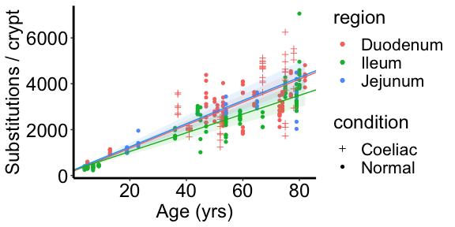

```r
tmp = data.frame(condition = c(3, 16))
tmp_name = c("Coeliac", "Normal")
rownames(tmp) = tmp_name

ggplot(data = df_regression, mapping = aes(x = age, y = sbs_count_adj)) +
    geom_point(aes(colour = region, fill = region, shape = condition)) +
    theme_bw() + theme(panel.grid = element_blank(), panel.border = element_blank(),
    axis.line = element_line(size = 1, colour = "black")) + scale_shape_manual(values = tmp$condition) +
    geom_abline(intercept = fixed.m1[1, ], slope = fixed.m1["age:regionDuodenum",
        ], colour = "#F8766D") + geom_ribbon(aes(ymin = fixed.m1[1, ] +
    age * intervals(lmm, which = "fixed")[["fixed"]]["age:regionDuodenum",
        "lower"], ymax = fixed.m1[1, ] + age * intervals(lmm, which = "fixed")[["fixed"]]["age:regionDuodenum",
    "upper"]), fill = "#F8766D", alpha = 0.1) + geom_abline(intercept = (fixed.m1[1,
    ] + fixed.m1["age:regionIleum", ]), slope = fixed.m1["age:regionIleum",
    ], colour = "#00B81F") + geom_ribbon(aes(ymin = fixed.m1[1, ] + fixed.m1["age:regionIleum",
    ] + age * intervals(lmm, which = "fixed")[["fixed"]]["age:regionIleum",
    "lower"], ymax = fixed.m1[1, ] + fixed.m1["age:regionIleum", ] + age *
    intervals(lmm, which = "fixed")[["fixed"]]["age:regionIleum", "upper"]),
    fill = "#00B81F", alpha = 0.1) + geom_abline(intercept = fixed.m1[1,
    ] + fixed.m1["age:regionJejunum", ], slope = fixed.m1["age:regionJejunum",
    ], colour = "#00A5FF") + geom_ribbon(aes(ymin = fixed.m1[1, ] + fixed.m1["age:regionJejunum",
    ] + age * intervals(lmm, which = "fixed")[["fixed"]]["age:regionJejunum",
    "lower"], ymax = fixed.m1[1, ] + fixed.m1["age:regionJejunum", ] +
    age * intervals(lmm, which = "fixed")[["fixed"]]["age:regionJejunum",
        "upper"]), fill = "#00A5FF", alpha = 0.1) + labs(y = "Substitutions / crypt",
    x = "Age (yrs)") + theme(title = element_text(size = 18), axis.text.y = element_text(size = 18,
    color = "black"), axis.text.x = element_text(size = 18, color = "black"),
    legend.text = element_text(size = 16))
```

### Indels

As above, we set up a linear mixed model for Indels with age as a fixed effect and patient as random effect.

```r
lmm.id.age <- lme(indel_count_adj ~ age, random = list(patient = pdDiag(form = ~age -
    1)), data = df_regression, method = "ML")
```

Adding seperate mutaion rate for duodenum/jejunum/ileum significantly improves the fitness of the model.

```r
# Whether biopsy regions affect Indel burden via slope
lmm.id.region.slope <- lme(indel_count_adj ~ age:region, random = list(patient = pdDiag(form = ~age -
    1)), data = df_regression, method = "ML")
anova(lmm.id.region.slope, lmm.id.age)
```

```
##                     Model df      AIC      BIC    logLik   Test  L.Ratio
## lmm.id.region.slope     1  6 3427.307 3449.648 -1707.653
## lmm.id.age              2  4 3440.465 3455.359 -1716.233 1 vs 2 17.15827
##                     p-value
## lmm.id.region.slope
## lmm.id.age            2e-04
```

Allowing different intercepts for different sections won’t further improve the model.

```r
# Whether biopsy regions affect Indel burden via slope and intercept
lmm.id.region.slope.intercept <- lme(indel_count_adj ~ age:region + region,
    random = list(patient = pdDiag(form = ~age - 1)), data = df_regression,
    method = "ML")
anova(lmm.id.region.slope.intercept, lmm.id.region.slope)
```

```
##                               Model df      AIC      BIC    logLik   Test
## lmm.id.region.slope.intercept     1  8 3430.449 3460.238 -1707.225
## lmm.id.region.slope               2  6 3427.307 3449.648 -1707.653 1 vs 2
##                                 L.Ratio p-value
## lmm.id.region.slope.intercept
## lmm.id.region.slope           0.8579112  0.6512
```

No significant inter-patient variation is caused by different biopsy sections, but adding different intra-patient variation can improve the fitness of the model.

```r
# Biopsy region does not affect between-patient variation of Indels
lmm.id.region.slope.var.inter <- lme(indel_count_adj ~ age:region, random = list(patient = pdDiag(form = ~age +
    region - 1)), data = df_regression, method = "ML")
anova(lmm.id.region.slope.var.inter, lmm.id.region.slope)
```

```
##                               Model df      AIC      BIC    logLik   Test
## lmm.id.region.slope.var.inter     1  9 3429.921 3463.433 -1705.960
## lmm.id.region.slope               2  6 3427.307 3449.648 -1707.653 1 vs 2
##                                L.Ratio p-value
## lmm.id.region.slope.var.inter
## lmm.id.region.slope           3.385962  0.3359
```

```r
# Biopsy region affects within-patient variation of Indels.The effect
# exist after removing possible outliers.
lmm.id.region.slope.var.intra <- lme(indel_count_adj ~ age:region, random = list(patient = pdDiag(form = ~age -
    1)), weights = varIdent(form = ~1 | region), data = df_regression,
    method = "ML")
anova(lmm.id.region.slope.var.intra, lmm.id.region.slope)
```

```
##                               Model df      AIC      BIC    logLik   Test
## lmm.id.region.slope.var.intra     1  8 3382.122 3411.911 -1683.061
## lmm.id.region.slope               2  6 3427.307 3449.648 -1707.653 1 vs 2
##                                L.Ratio p-value
## lmm.id.region.slope.var.intra
## lmm.id.region.slope           49.18453  <.0001
```

```r
lmm.id.region.slope <- lme(indel_count_adj ~ age:region, random = list(patient = pdDiag(form = ~age -
    1)), data = df_regression[which(df_regression$patient != "PD46565"),
    ], method = "ML")
lmm.id.region.slope.var.intra <- lme(indel_count_adj ~ age:region, random = list(patient = pdDiag(form = ~age -
    1)), weights = varIdent(form = ~1 | region), data = df_regression[which(df_regression$patient !=
    "PD46565"), ], method = "ML")
anova(lmm.id.region.slope.var.intra, lmm.id.region.slope)
```

```
##                               Model df      AIC      BIC    logLik   Test
## lmm.id.region.slope.var.intra     1  8 3164.254 3193.750 -1574.127
## lmm.id.region.slope               2  6 3169.113 3191.235 -1578.556 1 vs 2
##                                L.Ratio p-value
## lmm.id.region.slope.var.intra
## lmm.id.region.slope           8.859028  0.0119
```

Coeliac history does not affect Indel burdens, but affects intra-patient variation.

```r
# Coeliac history does not affect Indel burdens
lmm.id.region.slope <- lme(indel_count_adj ~ age:region, random = list(patient = pdDiag(form = ~age -
    1)), data = df_regression, method = "ML")
lmm.id.region.burden.coeliac.burden <- lme(indel_count_adj ~ age:region +
    age:condition + condition, random = list(patient = pdDiag(form = ~age -
    1)), data = df_regression, method = "ML")
anova(lmm.id.region.burden.coeliac.burden, lmm.id.region.slope)
```

```
##                                     Model df      AIC      BIC    logLik   Test
## lmm.id.region.burden.coeliac.burden     1  8 3425.973 3455.762 -1704.987
## lmm.id.region.slope                     2  6 3427.307 3449.648 -1707.653 1 vs 2
##                                      L.Ratio p-value
## lmm.id.region.burden.coeliac.burden
## lmm.id.region.slope                 5.333578  0.0695
```

```r
# Coeliac history does not affect inter-patient variation of Indels
lmm.id.region.slope.coeliac.var.inter <- lme(indel_count_adj ~ age:region,
    random = list(patient = pdDiag(form = ~age + condition - 1)), weights = varIdent(form = ~1 |
        region), data = df_regression, method = "ML")
lmm.id.region.slope.var.intra <- lme(indel_count_adj ~ age:region, random = list(patient = pdDiag(form = ~age -
    1)), weights = varIdent(form = ~1 | region), data = df_regression,
    method = "ML")
anova(lmm.id.region.slope.coeliac.var.inter, lmm.id.region.slope.var.intra)
```

```
##                                       Model df      AIC      BIC    logLik
## lmm.id.region.slope.coeliac.var.inter     1 10 3380.747 3417.983 -1680.374
## lmm.id.region.slope.var.intra             2  8 3382.122 3411.911 -1683.061
##                                         Test L.Ratio p-value
## lmm.id.region.slope.coeliac.var.inter
## lmm.id.region.slope.var.intra         1 vs 2 5.37495  0.0681
```

```r
# Coeliac history affects intra-patient variation of Indels. The
# effect exist after removing possible outliers.
lmm.id.region.slope.coeliac.var.intra <- lme(indel_count_adj ~ age:region,
    random = list(patient = pdDiag(form = ~age - 1)), weights = varIdent(form = ~1 |
        condition * region), data = df_regression, method = "ML")
lmm.id.region.slope.var.intra <- lme(indel_count_adj ~ age:region, random = list(patient = pdDiag(form = ~age -
    1)), weights = varIdent(form = ~1 | region), data = df_regression,
    method = "ML")
anova(lmm.id.region.slope.coeliac.var.intra, lmm.id.region.slope.var.intra)
```

```
##                                       Model df      AIC      BIC    logLik
## lmm.id.region.slope.coeliac.var.intra     1  9 3330.176 3363.688 -1656.088
## lmm.id.region.slope.var.intra             2  8 3382.122 3411.911 -1683.061
##                                         Test  L.Ratio p-value
## lmm.id.region.slope.coeliac.var.intra
## lmm.id.region.slope.var.intra         1 vs 2 53.94617  <.0001
```

```r
lmm.id.region.slope.var.intra.coeliac.var.intra <- lme(indel_count_adj ~
    age:region, random = list(patient = pdDiag(form = ~age - 1)), weights = varIdent(form = ~1 |
    condition * region), data = df_regression[which(df_regression$patient !=
    "PD46565"), ], method = "ML")
lmm.id.region.slope.var.intra <- lme(indel_count_adj ~ age:region, random = list(patient = pdDiag(form = ~age -
    1)), weights = varIdent(form = ~1 | region), data = df_regression[which(df_regression$patient !=
    "PD46565"), ], method = "ML")
anova(lmm.id.region.slope.var.intra.coeliac.var.intra, lmm.id.region.slope.var.intra)
```

```
##                                                 Model df      AIC      BIC
## lmm.id.region.slope.var.intra.coeliac.var.intra     1  9 3156.651 3189.834
## lmm.id.region.slope.var.intra                       2  8 3164.254 3193.750
##                                                    logLik   Test  L.Ratio
## lmm.id.region.slope.var.intra.coeliac.var.intra -1569.325
## lmm.id.region.slope.var.intra                   -1574.127 1 vs 2 9.602815
##                                                 p-value
## lmm.id.region.slope.var.intra.coeliac.var.intra
## lmm.id.region.slope.var.intra                    0.0019
```

Taking coeliac history into consideration, we can have a reasonabely good model without adding biospy regions as a factor affecting intra-patient variation.

```r
lmm.id.region.slope.var.intra.coeliac.var.intra <- lme(indel_count_adj ~
    age:region, random = list(patient = pdDiag(form = ~age - 1)), weights = varIdent(form = ~1 |
    condition * region), data = df_regression, method = "ML")
lmm.id.region.slope.coeliac.var.intra <- lme(indel_count_adj ~ age:region,
    random = list(patient = pdDiag(form = ~age - 1)), weights = varIdent(form = ~1 |
        condition), data = df_regression, method = "ML")
anova(lmm.id.region.slope.var.intra.coeliac.var.intra, lmm.id.region.slope.coeliac.var.intra)
```

```
##                                                 Model df      AIC      BIC
## lmm.id.region.slope.var.intra.coeliac.var.intra     1  9 3330.176 3363.688
## lmm.id.region.slope.coeliac.var.intra               2  7 3327.235 3353.300
##                                                    logLik   Test  L.Ratio
## lmm.id.region.slope.var.intra.coeliac.var.intra -1656.088
## lmm.id.region.slope.coeliac.var.intra           -1656.618 1 vs 2 1.058818
##                                                 p-value
## lmm.id.region.slope.var.intra.coeliac.var.intra
## lmm.id.region.slope.coeliac.var.intra             0.589
```

Therefore, our final model for ID burden includes both age and biopsy region as fixed effects, patient as a random effect, and use different covariance matrix for individual with/without a coeliac history.

```r
lmm <- lmm.id.region.slope.coeliac.var.intra
fixed.m1 <- data.frame(fixef(lmm))
intervals(lmm, which = "fixed")
```

```
## Approximate 95% confidence intervals
##
##  Fixed effects:
##                       lower      est.     upper
## (Intercept)        7.963765 22.826440 37.689115
## age:regionDuodenum 3.324744  3.957971  4.591198
## age:regionIleum    1.631853  2.359060  3.086266
## age:regionJejunum  1.928660  2.790635  3.652610
## attr(,"label")
## [1] "Fixed effects:"
```

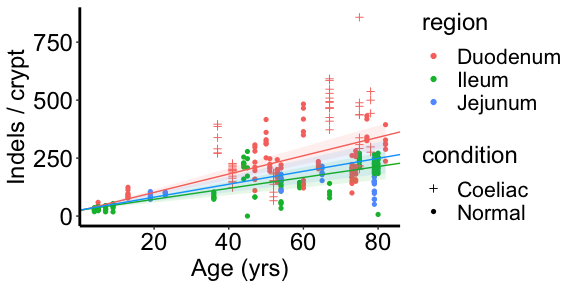

```r
tmp = data.frame(condition = c(3, 16))
tmp_name = c("Coeliac", "Normal")
rownames(tmp) = tmp_name

ggplot(data = df_regression, mapping = aes(x = age, y = indel_count_adj)) +
    geom_point(aes(colour = region, fill = region, shape = condition)) +
    theme_bw() + theme(panel.grid = element_blank(), panel.border = element_blank(),
    axis.line = element_line(size = 1, colour = "black")) + scale_shape_manual(values = tmp$condition) +
    geom_abline(intercept = fixed.m1[1, ], slope = fixed.m1["age:regionDuodenum",
        ], colour = "#F8766D") + geom_ribbon(aes(ymin = fixed.m1[1, ] +
    age * intervals(lmm, which = "fixed")[["fixed"]]["age:regionDuodenum",
        "lower"], ymax = fixed.m1[1, ] + age * intervals(lmm, which = "fixed")[["fixed"]]["age:regionDuodenum",
    "upper"]), fill = "#F8766D", alpha = 0.1) + geom_abline(intercept = (fixed.m1[1,
    ] + fixed.m1["age:regionIleum", ]), slope = fixed.m1["age:regionIleum",
    ], colour = "#00B81F") + geom_ribbon(aes(ymin = fixed.m1[1, ] + fixed.m1["age:regionIleum",
    ] + age * intervals(lmm, which = "fixed")[["fixed"]]["age:regionIleum",
    "lower"], ymax = fixed.m1[1, ] + fixed.m1["age:regionIleum", ] + age *
    intervals(lmm, which = "fixed")[["fixed"]]["age:regionIleum", "upper"]),
    fill = "#00B81F", alpha = 0.1) + geom_abline(intercept = fixed.m1[1,
    ] + fixed.m1["age:regionJejunum", ], slope = fixed.m1["age:regionJejunum",
    ], colour = "#00A5FF") + geom_ribbon(aes(ymin = fixed.m1[1, ] + fixed.m1["age:regionJejunum",
    ] + age * intervals(lmm, which = "fixed")[["fixed"]]["age:regionJejunum",
    "lower"], ymax = fixed.m1[1, ] + fixed.m1["age:regionJejunum", ] +
    age * intervals(lmm, which = "fixed")[["fixed"]]["age:regionJejunum",
        "upper"]), fill = "#00A5FF", alpha = 0.1) + labs(y = "Indels / crypt",
    x = "Age (yrs)") + theme(title = element_text(size = 18), axis.text.y = element_text(size = 18,
    color = "black"), axis.text.x = element_text(size = 18, color = "black"),
    legend.text = element_text(size = 16))
```

## 3. Mosiac plot for all signatures

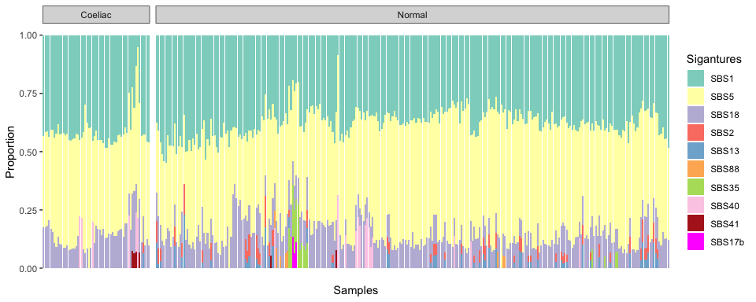

```r
df = exposure_matrix_crypts[rownames(exposure_matrix_crypts) %in% data$sample,
    ]
df$patient = rownames(df)
df$age = data$age
df$patient = fct_reorder(df$patient, df$age, min)

test <- gather(df, E1, E2, -patient, -age)
test$E1 <- factor(test$E1, levels = c("SBS1", "SBS5", "SBS18", "SBS2",
    "SBS13", "SBS88", "SBS35", "SBS40", "SBS41", "SBS17b"))
test$group = "Normal"
test$group[test$patient %in% data$sample[data$condition == "Coeliac"]] = "Coeliac"

sig_order = 1:10
names(sig_order) = c("SBS1", "SBS5", "SBS18", "SBS2", "SBS13", "SBS88",
    "SBS35", "SBS40", "SBS41", "SBS17b")
final_sigs = t(read.table("./data/sigs/final_sigs.txt", check.names = FALSE))

getPalette = colorRampPalette(brewer.pal(8, "Set3"))
all_cols = getPalette(8)
all_cols = c(all_cols, "firebrick", "magenta")
final_sigs = final_sigs[names(sort(sig_order[rownames(final_sigs)])), ]
names(all_cols) = rownames(final_sigs)

ggplot(test, aes(x = patient, y = E2, fill = E1)) + geom_bar(stat = "identity") +
    scale_fill_manual(values = all_cols) + theme_bw() + theme(axis.text.x = element_blank(),
    axis.ticks.x = element_blank(), panel.grid = element_blank(), panel.border = element_blank()) +
    labs(x = "Samples", y = "Proportion", fill = "Sigantures") + facet_grid(cols = vars(group),
    scales = "free_x", space = "free")
```

## 4. The presence of APOBEC signatures SBS2/13 in the small intestine

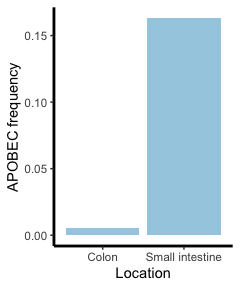

```r
exposure_matrix_all = read.table("./data/sigs/exposure_matrix_with_colon.txt",
    header = T, stringsAsFactors = F)
input_for_hdp <- read.table("./data/input_for_hdp.txt", check.names = F)
input_for_hdp = input_for_hdp[apply(input_for_hdp, 1, sum) > 50, ]
input_for_hdp = input_for_hdp[!(rownames(input_for_hdp) %in% c("PD43851_1",
    "PD43851_4", "PD43851_14")), ]

apobec_table = data.frame(matrix(ncol = 2, nrow = length(unique(data$patient))))
rownames(apobec_table) = unique(data$patient)
colnames(apobec_table) = c("Positive", "Negative")
for (patient in unique(data$patient)) {
    apobec_table[patient, "Positive"] = sum(sum(data[data$patient == patient,
        "SBS2"] + data[data$patient == patient, "SBS13"] > 0.05 * data[data$patient ==
        patient, "sbs_count_adj"]))
    apobec_table[patient, "Negative"] = sum(data$patient == patient) -
        apobec_table[patient, "Positive"]
}

APOBEC_matrix_all = exposure_matrix_all[, c("SBS2", "SBS13")]
APOBEC_matrix_all$sum = APOBEC_matrix_all$SBS2 + APOBEC_matrix_all$SBS13
APOBEC_matrix_all$sum[APOBEC_matrix_all$sum < 0.05] = 0
APOBEC_matrix_all$group = "Colon"
APOBEC_matrix_all$group[rownames(exposure_matrix_all) %in% rownames(input_for_hdp)] = "Small intestine"
APOBEC_matrix_all$branch = rownames(APOBEC_matrix_all)

df = data.frame(matrix(ncol = 3, nrow = 2))
colnames(df) <- c("region", "pos", "neg")
df$region = c("Small intestine", "Colon")
df$pos = c(sum(APOBEC_matrix_all$sum[APOBEC_matrix_all$group == "Small intestine"] >
    0), sum(APOBEC_matrix_all$sum[APOBEC_matrix_all$group == "Colon"] >
    0))
df$neg = c(sum(APOBEC_matrix_all$sum[APOBEC_matrix_all$group == "Small intestine"] ==
    0), sum(APOBEC_matrix_all$sum[APOBEC_matrix_all$group == "Colon"] ==
    0))


df[1, 2:3] = df[1, 2:3]/sum(df[1, 2:3])
df[2, 2:3] = df[2, 2:3]/sum(df[2, 2:3])

test <- gather(df, E1, E2, -region)
test$E1 <- factor(test$E1, levels = c("pos", "neg"))


ggplot(test[test$E1 == "pos", ]) + geom_bar(aes(x = region, y = E2, fill = E1),
    stat = "identity") + scale_fill_brewer(palette = "Paired", labels = c("APOBEC positive",
    "APOBEC negative")) + theme_bw() + theme(panel.grid = element_blank(),
    legend.position = "none", legend.title = element_blank(), panel.border = element_blank(),
    axis.line = element_line(size = 1, colour = "black")) + labs(x = "Location",
    y = "APOBEC frequency")
```

## 5. Mutational burden for common mutational signatures in the normal small intestine

We looked into the accumulation of mutational buren across the corhort for SBS1, SBS5, SBS18 and SBS2/13. Other sporadic signatures are too rare for conducting meaningful statistical analysis.

### SBS1

The accumulation of SBS1 burden is asscoicated with age and differ in diifferent biopsy regions.

```r
lmm <- lme(SBS1 ~ age - 1, random = list(patient = pdDiag(form = ~age -
    1)), weights = varIdent(form = ~1), data = df_regression, method = "ML")

# Biopsy region affects SBS1 burden
lmm.region.burden <- lme(SBS1 ~ age:region - 1, random = list(patient = pdDiag(form = ~age -
    1)), data = df_regression, method = "ML")
anova(lmm.region.burden, lmm)
```

```
##                   Model df      AIC      BIC    logLik   Test L.Ratio p-value
## lmm.region.burden     1  5 4274.398 4293.016 -2132.199
## lmm                   2  3 4281.990 4293.161 -2137.995 1 vs 2 11.5924   0.003
```

```r
# Coeliac history does not affect SBS1 burden
lmm.coeliac.burden <- lme(SBS1 ~ age:region + age:condition - 1, random = list(patient = pdDiag(form = ~age -
    1)), data = df_regression, method = "ML")
anova(lmm.coeliac.burden, lmm.region.burden)
```

```
##                    Model df      AIC      BIC    logLik   Test  L.Ratio p-value
## lmm.coeliac.burden     1  6 4272.836 4295.178 -2130.418
## lmm.region.burden      2  5 4274.398 4293.016 -2132.199 1 vs 2 3.561346  0.0591
```

```r
lmm <- lmm.region.burden
fixed.m1 <- data.frame(fixef(lmm))

intervals(lmm, which = "fixed")
```

```
## Approximate 95% confidence intervals
##
##  Fixed effects:
##                       lower     est.    upper
## age:regionDuodenum 19.18020 21.25171 23.32321
## age:regionIleum    13.51903 16.10529 18.69155
## age:regionJejunum  15.79575 19.43491 23.07407
## attr(,"label")
## [1] "Fixed effects:"
```

```r
cor(df_regression$SBS1, df_regression$age, method = "pearson")
```

```
## [1] 0.7650977
```

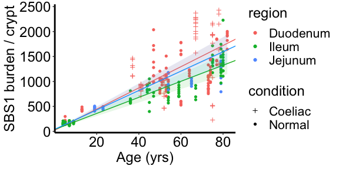

```r
tmp = data.frame(condition = c(3, 16))
tmp_name = c("Coeliac", "Normal")
rownames(tmp) = tmp_name

ggplot(data = df_regression, mapping = aes(x = age, y = SBS1)) + geom_point(aes(colour = region,
    fill = region, shape = condition)) + theme_bw() + theme(panel.grid = element_blank(),
    panel.border = element_blank(), axis.line = element_line(size = 1,
        colour = "black")) + scale_shape_manual(values = tmp$condition) +
    geom_abline(intercept = fixed.m1[1, ], slope = fixed.m1["age:regionDuodenum",
        ], colour = "#F8766D") + geom_ribbon(aes(ymin = fixed.m1[1, ] +
    age * intervals(lmm, which = "fixed")[["fixed"]]["age:regionDuodenum",
        "lower"], ymax = fixed.m1[1, ] + age * intervals(lmm, which = "fixed")[["fixed"]]["age:regionDuodenum",
    "upper"]), fill = "#F8766D", alpha = 0.1) + geom_abline(intercept = (fixed.m1[1,
    ] + fixed.m1["age:regionIleum", ]), slope = fixed.m1["age:regionIleum",
    ], colour = "#00B81F") + geom_ribbon(aes(ymin = fixed.m1[1, ] + fixed.m1["age:regionIleum",
    ] + age * intervals(lmm, which = "fixed")[["fixed"]]["age:regionIleum",
    "lower"], ymax = fixed.m1[1, ] + fixed.m1["age:regionIleum", ] + age *
    intervals(lmm, which = "fixed")[["fixed"]]["age:regionIleum", "upper"]),
    fill = "#00B81F", alpha = 0.1) + geom_abline(intercept = fixed.m1[1,
    ] + fixed.m1["age:regionJejunum", ], slope = fixed.m1["age:regionJejunum",
    ], colour = "#00A5FF") + geom_ribbon(aes(ymin = fixed.m1[1, ] + fixed.m1["age:regionJejunum",
    ] + age * intervals(lmm, which = "fixed")[["fixed"]]["age:regionJejunum",
    "lower"], ymax = fixed.m1[1, ] + fixed.m1["age:regionJejunum", ] +
    age * intervals(lmm, which = "fixed")[["fixed"]]["age:regionJejunum",
        "upper"]), fill = "#00A5FF", alpha = 0.1) + labs(y = "SBS1 burden / crypt",
    x = "Age (yrs)") + theme(title = element_text(size = 18), axis.text.y = element_text(size = 18,
    color = "black"), axis.text.x = element_text(size = 18, color = "black"),
    legend.text = element_text(size = 16))
```

### SBS5

```r
lmm <- lme(SBS5 ~ age, random = list(patient = pdDiag(form = ~age - 1)),
    weights = varIdent(form = ~1), data = df_regression, method = "ML")

# Coeliac history does not affect SBS5 burden
lmm.coeliac.burden <- lme(SBS5 ~ age:condition, random = list(patient = pdDiag(form = ~age -
    1)), data = df_regression, method = "ML")
anova(lmm.coeliac.burden, lmm)
```

```
##                    Model df      AIC      BIC    logLik   Test   L.Ratio
## lmm.coeliac.burden     1  5 4184.870 4203.488 -2087.435
## lmm                    2  4 4183.119 4198.013 -2087.559 1 vs 2 0.2486619
##                    p-value
## lmm.coeliac.burden
## lmm                  0.618
```

```r
# Biopsy region does not affect SBS5 burden
lmm.region.burden <- lme(SBS5 ~ age:region, random = list(patient = pdDiag(form = ~age -
    1)), data = df_regression, method = "ML")
anova(lmm.region.burden, lmm)
```

```
##                   Model df      AIC      BIC    logLik   Test  L.Ratio p-value
## lmm.region.burden     1  6 4180.603 4202.945 -2084.302
## lmm                   2  4 4183.119 4198.013 -2087.559 1 vs 2 6.515872  0.0385
```

```r
fixed.m1 <- data.frame(fixef(lmm))
intervals(lmm, which = "fixed")
```

```
## Approximate 95% confidence intervals
##
##  Fixed effects:
##                 lower     est.    upper
## (Intercept) -38.19893 26.32598 90.85088
## age          21.43214 23.31747 25.20281
## attr(,"label")
## [1] "Fixed effects:"
```

```r
cor(df_regression$SBS5, df_regression$age, method = "pearson")
```

```
## [1] 0.8986329
```

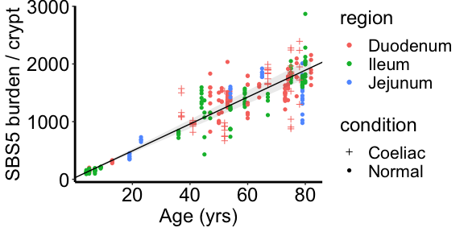

```r
tmp = data.frame(condition = c(3, 16))
tmp_name = c("Coeliac", "Normal")
rownames(tmp) = tmp_name

ggplot(data = df_regression, mapping = aes(x = age, y = SBS5)) + geom_point(aes(colour = region,
    fill = region, shape = condition)) + theme_bw() + theme(panel.grid = element_blank(),
    panel.border = element_blank(), axis.line = element_line(size = 1,
        colour = "black")) + scale_shape_manual(values = tmp$condition) +
    geom_abline(intercept = fixed.m1[1, ], slope = fixed.m1["age", ]) +
    geom_ribbon(aes(ymin = fixed.m1[1, ] + age * intervals(lmm, which = "fixed")[["fixed"]]["age",
        "lower"], ymax = fixed.m1[1, ] + age * intervals(lmm, which = "fixed")[["fixed"]]["age",
        "upper"]), alpha = 0.1) + labs(y = "SBS5 burden / crypt", x = "Age (yrs)") +
    theme(title = element_text(size = 18), axis.text.y = element_text(size = 18,
        color = "black"), axis.text.x = element_text(size = 18, color = "black"),
        legend.text = element_text(size = 16))
```

### SBS18

The accumulation of SBS18 burden is asscoicated with age, but shows no difference across the three sections.

```r
lmm <- lme(SBS18 ~ age, random = list(patient = pdDiag(form = ~age - 1)),
    weights = varIdent(form = ~1), data = df_regression, method = "ML")

# Coeliac history does not affect SBS18 burden
lmm.coeliac.burden <- lme(SBS18 ~ age:condition, random = list(patient = pdDiag(form = ~age -
    1)), data = df_regression, method = "ML")
anova(lmm.coeliac.burden, lmm)
```

```
##                    Model df      AIC      BIC    logLik   Test  L.Ratio p-value
## lmm.coeliac.burden     1  5 3905.886 3924.504 -1947.943
## lmm                    2  4 3906.644 3921.539 -1949.322 1 vs 2 2.758576  0.0967
```

```r
# Biopsy region does not affect SBS18 burden
lmm.region.burden <- lme(SBS18 ~ age:region, random = list(patient = pdDiag(form = ~age -
    1)), data = df_regression, method = "ML")
anova(lmm.region.burden, lmm)
```

```
##                   Model df      AIC      BIC    logLik   Test  L.Ratio p-value
## lmm.region.burden     1  6 3908.474 3930.815 -1948.237
## lmm                   2  4 3906.644 3921.539 -1949.322 1 vs 2 2.170725  0.3378
```

```r
fixed.m1 <- data.frame(fixef(lmm))
intervals(lmm, which = "fixed")
```

```
## Approximate 95% confidence intervals
##
##  Fixed effects:
##                 lower      est.     upper
## (Intercept) -1.480919 40.401917 82.284754
## age          4.054601  5.399316  6.744031
## attr(,"label")
## [1] "Fixed effects:"
```

```r
cor(df_regression$SBS18, df_regression$age, method = "pearson")
```

```
## [1] 0.5770559
```

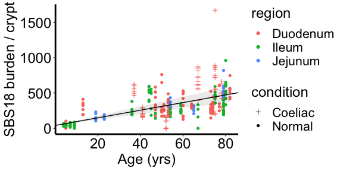

```r
tmp = data.frame(condition = c(3, 16))
tmp_name = c("Coeliac", "Normal")
rownames(tmp) = tmp_name

ggplot(data = df_regression, mapping = aes(x = age, y = SBS18)) + geom_point(aes(colour = region,
    fill = region, shape = condition)) + theme_bw() + theme(panel.grid = element_blank(),
    panel.border = element_blank(), axis.line = element_line(size = 1,
        colour = "black")) + scale_shape_manual(values = tmp$condition) +
    geom_abline(intercept = fixed.m1[1, ], slope = fixed.m1["age", ]) +
    geom_ribbon(aes(ymin = fixed.m1[1, ] + age * intervals(lmm, which = "fixed")[["fixed"]]["age",
        "lower"], ymax = fixed.m1[1, ] + age * intervals(lmm, which = "fixed")[["fixed"]]["age",
        "upper"]), alpha = 0.1) + labs(y = "SBS18 burden / crypt", x = "Age (yrs)") +
    theme(title = element_text(size = 18), axis.text.y = element_text(size = 18,
        color = "black"), axis.text.x = element_text(size = 18, color = "black"),
        legend.text = element_text(size = 16))
```

### SBS2

The accumulation of SBS2 burden has a non-linear relationship with age.

```r
lmm <- lme(SBS2 ~ age, random = list(patient = pdDiag(form = ~age - 1)),
    weights = varIdent(form = ~1), data = df_regression, method = "ML")

# Coeliac history does not affect SBS2 burden
lmm.coeliac.burden <- lme(SBS2 ~ age:condition, random = list(patient = pdDiag(form = ~age -
    1)), data = df_regression, method = "ML")
anova(lmm.coeliac.burden, lmm)
```

```
##                    Model df      AIC      BIC    logLik   Test  L.Ratio p-value
## lmm.coeliac.burden     1  5 3436.921 3455.539 -1713.460
## lmm                    2  4 3436.994 3451.888 -1714.497 1 vs 2 2.072959  0.1499
```

```r
# Biopsy region does not affect SBS2 burden
lmm.region.burden <- lme(SBS2 ~ age:region, random = list(patient = pdDiag(form = ~age -
    1)), data = df_regression, method = "ML")
anova(lmm.region.burden, lmm)
```

```
##                   Model df      AIC      BIC    logLik   Test  L.Ratio p-value
## lmm.region.burden     1  6 3436.662 3459.004 -1712.331
## lmm                   2  4 3436.994 3451.888 -1714.497 1 vs 2 4.331504  0.1147
```

```r
fixed.m1 <- data.frame(fixef(lmm))
intervals(lmm, which = "fixed")
```

```
## Approximate 95% confidence intervals
##
##  Fixed effects:
##                    lower      est.      upper
## (Intercept) -11.74141443 6.6931431 25.1277007
## age          -0.07270866 0.3627143  0.7981373
## attr(,"label")
## [1] "Fixed effects:"
```

```r
cor(df_regression$SBS2, df_regression$age, method = "pearson")
```

```
## [1] 0.1914581
```

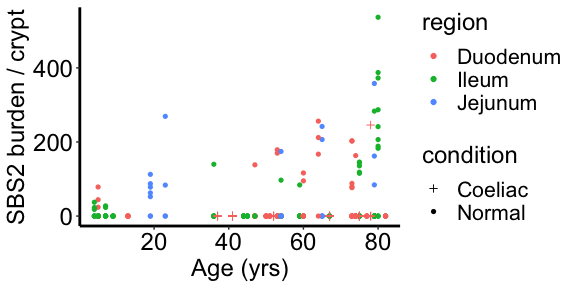

```r
tmp = data.frame(condition = c(3, 16))
tmp_name = c("Coeliac", "Normal")
rownames(tmp) = tmp_name

ggplot(data = df_regression, mapping = aes(x = age, y = SBS2)) + geom_point(aes(colour = region,
    fill = region, shape = condition)) + theme_bw() + theme(panel.grid = element_blank(),
    panel.border = element_blank(), axis.line = element_line(size = 1,
        colour = "black")) + scale_shape_manual(values = tmp$condition) +
    labs(y = "SBS2 burden / crypt", x = "Age (yrs)") + theme(title = element_text(size = 18),
    axis.text.y = element_text(size = 18, color = "black"), axis.text.x = element_text(size = 18,
        color = "black"), legend.text = element_text(size = 16))
```

### SBS13

The accumulation of SBS13 burden has a non-linear relationship with age.

```r
lmm <- lme(SBS13 ~ age, random = list(patient = pdDiag(form = ~age - 1)),
    weights = varIdent(form = ~1), data = df_regression, method = "ML")

# Coeliac history does not affect SBS13 burden
lmm.coeliac.burden <- lme(SBS13 ~ age:condition, random = list(patient = pdDiag(form = ~age -
    1)), data = df_regression, method = "ML")
anova(lmm.coeliac.burden, lmm)
```

```
##                    Model df     AIC      BIC    logLik   Test  L.Ratio p-value
## lmm.coeliac.burden     1  5 3480.91 3499.528 -1735.455
## lmm                    2  4 3480.47 3495.364 -1736.235 1 vs 2 1.559412  0.2118
```

```r
# Biopsy region does not affect SBS13 burden
lmm.region.burden <- lme(SBS13 ~ age:region, random = list(patient = pdDiag(form = ~age -
    1)), data = df_regression, method = "ML")
anova(lmm.region.burden, lmm)
```

```
##                   Model df      AIC      BIC    logLik   Test L.Ratio p-value
## lmm.region.burden     1  6 3479.568 3501.910 -1733.784
## lmm                   2  4 3480.470 3495.364 -1736.235 1 vs 2 4.90158  0.0862
```

```r
fixed.m1 <- data.frame(fixef(lmm))
intervals(lmm, which = "fixed")
```

```
## Approximate 95% confidence intervals
##
##  Fixed effects:
##                    lower      est.      upper
## (Intercept) -15.36302292 4.2595222 23.8820673
## age          -0.04956751 0.3884761  0.8265198
## attr(,"label")
## [1] "Fixed effects:"
```

```r
cor(df_regression$SBS13, df_regression$age, method = "pearson")
```

```
## [1] 0.1832436
```

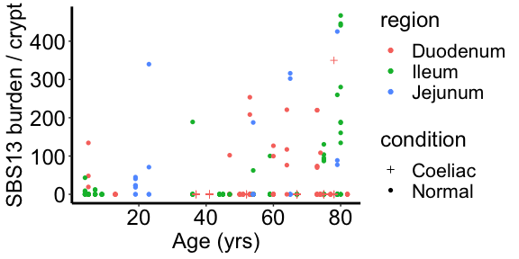

```r
tmp = data.frame(condition = c(3, 16))
tmp_name = c("Coeliac", "Normal")
rownames(tmp) = tmp_name

ggplot(data = df_regression, mapping = aes(x = age, y = SBS13)) + geom_point(aes(colour = region,
    fill = region, shape = condition)) + theme_bw() + theme(panel.grid = element_blank(),
    panel.border = element_blank(), axis.line = element_line(size = 1,
        colour = "black")) + scale_shape_manual(values = tmp$condition) +
    labs(y = "SBS13 burden / crypt", x = "Age (yrs)") + theme(title = element_text(size = 18),
    axis.text.y = element_text(size = 18, color = "black"), axis.text.x = element_text(size = 18,
        color = "black"), legend.text = element_text(size = 16))
```